# Classification of DNA Splice Junctions

by Salomon Marquez

25/06/2025

Splice junctions are points within a DNA sequence where “superfluous” DNA is removed during the protein synthesis process in higher organisms.

To predict the type of splicing site, several machine learning algorithms will be implemented, including: k-Nearest Neighbour, Naive Bayes, Artificial Neural Network, Support Vector Machine, Decision Tree, and Random Forest. Finally, the following metrics will be evaluated: precision, recall, f1-score, and error, in order to determine which algorithms performed best for this task.

## 1 Installation of Dependencies and Setup of the Working Directory

```python
import numpy as np
import pandas as pd
import os
import random
import matplotlib.pyplot as plt
import seaborn as sns

from sklearn.model_selection import train_test_split
from sklearn.neighbors import KNeighborsClassifier
from sklearn.metrics import confusion_matrix, accuracy_score
from sklearn.metrics import classification_report
from sklearn.metrics import roc_curve, roc_auc_score
from sklearn.naive_bayes import BernoulliNB
from sklearn.naive_bayes import GaussianNB
from sklearn.naive_bayes import MultinomialNB
from sklearn.naive_bayes import CategoricalNB
from sklearn.svm import SVC
from sklearn.tree import DecisionTreeClassifier
from sklearn.ensemble import GradientBoostingClassifier
from sklearn.ensemble import RandomForestClassifier

import tensorflow as tf
from tensorflow import keras
from tensorflow.keras.models import Model, Sequential
from tensorflow.keras.layers import Input, Conv1D, Conv1DTranspose, Flatten, Dense, Reshape, Dropout

from IPython.display import Image
```

import numpy as np import pandas as pd import os import random import matplotlib.pyplot as plt import seaborn as sns from sklearn.model_selection import train_test_split from sklearn.neighbors import KNeighborsClassifier from sklearn.metrics import confusion_matrix, accuracy_score from sklearn.metrics import classification_report from sklearn.metrics import roc_curve, roc_auc_score from sklearn.naive_bayes import BernoulliNB from sklearn.naive_bayes import GaussianNB from sklearn.naive_bayes import MultinomialNB from sklearn.naive_bayes import CategoricalNB from sklearn.svm import SVC from sklearn.tree import DecisionTreeClassifier from sklearn.ensemble import GradientBoostingClassifier from sklearn.ensemble import RandomForestClassifier import tensorflow as tf from tensorflow import keras from tensorflow.keras.models import Model, Sequential from tensorflow.keras.layers import Input, Conv1D, Conv1DTranspose, Flatten, Dense, Reshape, Dropout from IPython.display import Image

```python
# Fijar semilla para obtener resultados reproducibles cuando se ejecuta el notebook
# Fijar la semilla
seed_value = 123
os.environ['PYTHONHASHSEED'] = str(seed_value)
random.seed(seed_value)
np.random.seed(seed_value)
tf.random.set_seed(seed_value)
```

# Fijar semilla para obtener resultados reproducibles cuando se ejecuta el notebook # Fijar la semilla seed_value = 123 os.environ['PYTHONHASHSEED'] = str(seed_value) random.seed(seed_value) np.random.seed(seed_value) tf.random.set_seed(seed_value)

```python
# Obtener el directorio actual
actual_wd = os.getcwd()
print("Ruta actual:", actual_wd)

# Establecer directorio de trabajo en Gdrive
# os.chdir("/content/drive/MyDrive/ASIGNATURAS/M0.163 MACHINE LEARNING/[28 MAY - 17 JUN] RETO 4/PEC4")
```

# Obtener el directorio actual actual_wd = os.getcwd() print("Ruta actual:", actual_wd) # Establecer directorio de trabajo en Gdrive # os.chdir("/content/drive/MyDrive/ASIGNATURAS/M0.163 MACHINE LEARNING/[28 MAY - 17 JUN] RETO 4/PEC4")

```python
# Visualizar contenido del directorio de trabajo
!ls
```

# Visualizar contenido del directorio de trabajo !ls

```
autoencoder_image.png	 enunciado_PEC4_2425_2.pdf    splice.csv
deep_descriptors.csv	 PEC4_Machine_Learning.html
deep_descriptors.gsheet  PEC4_Machine_Learning.ipynb
```

## 2 Data Reading and Preparation

In this section, we will answer some general questions about the dataset contained in the file `splice.csv`

### 2.1 Read Data

```python
# Especificar el nombre del archivo de origen
file_name = "splice.csv"
file_path = os.path.join(actual_wd, file_name)
```

# Especificar el nombre del archivo de origen file_name = "splice.csv" file_path = os.path.join(actual_wd, file_name)

```python
# Guardar en un dataframe el contenido de splice.csv
df_splice = pd.read_csv(file_path, delimiter=',')
```

# Guardar en un dataframe el contenido de splice.csv df_splice = pd.read_csv(file_path, delimiter=',')

```python
# Visualizar contenido del dataframe splice
df_splice.info()
```

# Visualizar contenido del dataframe splice df_splice.info()

```
<class 'pandas.core.frame.DataFrame'>
RangeIndex: 3190 entries, 0 to 3189
Columns: 482 entries, class to V480
dtypes: int64(480), object(2)
memory usage: 11.7+ MB
```

```python
# Visualizar las 5 primeras filas
df_splice.head(5)
```

# Visualizar las 5 primeras filas df_splice.head(5)

|  | class | seq_name | V1 | V2 | V3 | V4 | V5 | V6 | V7 | V8 | ... | V471 | V472 | V473 | V474 | V475 | V476 | V477 | V478 | V479 | V480 |
| --- | --- | --- | --- | --- | --- | --- | --- | --- | --- | --- | --- | --- | --- | --- | --- | --- | --- | --- | --- | --- | --- |
| 0 | EI | ATRINS-DONOR-521 | 0 | 0 | 0 | 1 | 0 | 0 | 0 | 0 | ... | 0 | 0 | 0 | 1 | 0 | 0 | 0 | 0 | 0 | 0 |
| 1 | EI | ATRINS-DONOR-905 | 1 | 0 | 0 | 0 | 0 | 0 | 0 | 0 | ... | 0 | 0 | 0 | 0 | 0 | 1 | 0 | 0 | 0 | 0 |
| 2 | EI | BABAPOE-DONOR-30 | 0 | 1 | 0 | 0 | 0 | 0 | 0 | 0 | ... | 0 | 0 | 0 | 1 | 0 | 0 | 0 | 0 | 0 | 0 |
| 3 | EI | BABAPOE-DONOR-867 | 0 | 1 | 0 | 0 | 0 | 0 | 0 | 0 | ... | 0 | 0 | 0 | 0 | 0 | 1 | 0 | 0 | 0 | 0 |
| 4 | EI | BABAPOE-DONOR-2817 | 0 | 1 | 0 | 0 | 0 | 0 | 0 | 0 | ... | 0 | 0 | 0 | 0 | 1 | 0 | 0 | 0 | 0 | 0 |

5 rows × 482 columns

```python
# Visualizar las 5 últimas filas
df_splice.tail(5)
```

# Visualizar las 5 últimas filas df_splice.tail(5)

|  | class | seq_name | V1 | V2 | V3 | V4 | V5 | V6 | V7 | V8 | ... | V471 | V472 | V473 | V474 | V475 | V476 | V477 | V478 | V479 | V480 |
| --- | --- | --- | --- | --- | --- | --- | --- | --- | --- | --- | --- | --- | --- | --- | --- | --- | --- | --- | --- | --- | --- |
| 3185 | N | ORAHBPSBD-NEG-2881 | 0 | 0 | 1 | 0 | 0 | 0 | 0 | 0 | ... | 0 | 0 | 0 | 0 | 1 | 0 | 0 | 0 | 0 | 0 |
| 3186 | N | ORAINVOL-NEG-2161 | 0 | 1 | 0 | 0 | 0 | 0 | 0 | 0 | ... | 0 | 0 | 0 | 1 | 0 | 0 | 0 | 0 | 0 | 0 |
| 3187 | N | ORARGIT-NEG-241 | 0 | 0 | 1 | 0 | 0 | 0 | 0 | 0 | ... | 0 | 0 | 0 | 0 | 0 | 1 | 0 | 0 | 0 | 0 |
| 3188 | N | TARHBB-NEG-541 | 1 | 0 | 0 | 0 | 0 | 0 | 0 | 0 | ... | 0 | 0 | 1 | 0 | 0 | 0 | 0 | 0 | 0 | 0 |
| 3189 | N | TARHBD-NEG-1981 | 1 | 0 | 0 | 0 | 0 | 0 | 0 | 0 | ... | 0 | 0 | 0 | 0 | 1 | 0 | 0 | 0 | 0 | 0 |

5 rows × 482 columns

### 2.2 How many unique `seq_name` entries does the dataset have?

```python
# Obtener el número de secuencias únicas
n_unique = df_splice['seq_name'].nunique()
n_unique
```

# Obtener el número de secuencias únicas n_unique = df_splice['seq_name'].nunique() n_unique

```
3178
```

```python
# Calcular el número de secuencias repetidas
print(f"El dataset contiene {len(df_splice)-n_unique} secuencia repetidas")
```

# Calcular el número de secuencias repetidas print(f"El dataset contiene {len(df_splice)-n_unique} secuencia repetidas")

```
El dataset contiene 12 secuencia repetidas
```

```python
# Alternativamente para calcular duplicados
df_splice.duplicated().sum()
```

# Alternativamente para calcular duplicados df_splice.duplicated().sum()

```
np.int64(12)
```

```python
# Identificar las secuencias repetidas
df_splice_unique = df_splice['seq_name'].value_counts()
df_splice_unique.head(15)
```

# Identificar las secuencias repetidas df_splice_unique = df_splice['seq_name'].value_counts() df_splice_unique.head(15)

| seq_name | count |
| --- | --- |
| HUMMYC3L-ACCEPTOR-4242 | 2 |
| HUMALBGC-DONOR-17044 | 2 |
| HUMMYLCA-DONOR-2559 | 2 |
| HUMMYLCA-DONOR-2388 | 2 |
| HUMMYLCA-DONOR-1975 | 2 |
| HUMMYLCA-DONOR-952 | 2 |
| HUMALBGC-ACCEPTOR-18496 | 2 |
| HUMMYLCA-ACCEPTOR-924 | 2 |
| HUMMYLCA-ACCEPTOR-1831 | 2 |
| HUMMYLCA-ACCEPTOR-2214 | 2 |
| HUMMYLCA-ACCEPTOR-2481 | 2 |
| HUMMYLCA-DONOR-644 | 2 |
| HUMGAPJR-NEG-961 | 1 |
| HUMGBR-NEG-2521 | 1 |
| HUMGALAB-NEG-901 | 1 |

**dtype:** int64

```python
# Visualizar un par de secuencias repetidas
df_splice[df_splice['seq_name'].str.contains('HUMMYC3L-ACCEPTOR-4242')]
```

# Visualizar un par de secuencias repetidas df_splice[df_splice['seq_name'].str.contains('HUMMYC3L-ACCEPTOR-4242')]

|  | class | seq_name | V1 | V2 | V3 | V4 | V5 | V6 | V7 | V8 | ... | V471 | V472 | V473 | V474 | V475 | V476 | V477 | V478 | V479 | V480 |
| --- | --- | --- | --- | --- | --- | --- | --- | --- | --- | --- | --- | --- | --- | --- | --- | --- | --- | --- | --- | --- | --- |
| 1316 | IE | HUMMYC3L-ACCEPTOR-4242 | 0 | 0 | 1 | 0 | 0 | 0 | 0 | 0 | ... | 0 | 0 | 0 | 1 | 0 | 0 | 0 | 0 | 0 | 0 |
| 1317 | IE | HUMMYC3L-ACCEPTOR-4242 | 0 | 0 | 1 | 0 | 0 | 0 | 0 | 0 | ... | 0 | 0 | 0 | 1 | 0 | 0 | 0 | 0 | 0 | 0 |

2 rows × 482 columns

```python
# Eliminar duplicados
df_splice_n = df_splice.drop_duplicates()
print(f"El dataset originalmente contenía {len(df_splice)} registros y después de eliminar duplicados se tienen {len(df_splice_n)} registros ")
```

# Eliminar duplicados df_splice_n = df_splice.drop_duplicates() print(f"El dataset originalmente contenía {len(df_splice)} registros y después de eliminar duplicados se tienen {len(df_splice_n)} registros ")

```
El dataset originalmente contenía 3190 registros y después de eliminar duplicados se tienen 3178 registros
```

### 2.3 How many label types exist?

```python
df_splice_label = df_splice_n['class'].value_counts()
df_splice_label
```

df_splice_label = df_splice_n['class'].value_counts() df_splice_label

| class | count |
| --- | --- |
| N | 1655 |
| IE | 762 |
| EI | 761 |

**dtype:** int64

We have an imbalanced dataset where slightly more than 50% of the sequences belong to the “no splicing” category. This must be taken into account because the classification models proposed below could become biased toward predicting "N."

### 2.4 Prepare the encoded sequences in the dataset

Here we define the variable `seq_encoded`, which will contain the 3,178 records and their 480 features.

```python
# Seleccionar desde V1 hasta V480
seq_encoded = df_splice_n.iloc[:,2:]
```

# Seleccionar desde V1 hasta V480 seq_encoded = df_splice_n.iloc[:,2:]

```python
# Verificar el tipo de variable
type(seq_encoded)
```

# Verificar el tipo de variable type(seq_encoded)

[output not shown]

[output not shown]

[output cut: 76 more lines]

[output not shown]

```python
# Convertir datos a numpy.array
seq_encoded_array = seq_encoded.to_numpy()
seq_encoded_array[:5]
```

# Convertir datos a numpy.array seq_encoded_array = seq_encoded.to_numpy() seq_encoded_array[:5]

```
array([[0, 0, 0, ..., 0, 0, 0],
       [1, 0, 0, ..., 0, 0, 0],
       [0, 1, 0, ..., 0, 0, 0],
       [0, 1, 0, ..., 0, 0, 0],
       [0, 1, 0, ..., 0, 0, 0]])
```

### 2.5 Prepare the dataset labels

The `Class` variable in the splicing dataset has three categories: EI, IE, and N. No particular positive class is defined here. This variable must be converted to a numeric type so it can be used in our classification models.

```python
labels = df_splice_n['class'].map({'EI': 0, 'IE': 1, 'N': 2})
```

labels = df_splice_n['class'].map({'EI': 0, 'IE': 1, 'N': 2})

```python
# Convertir datos a numpy.array
labels_array = labels.to_numpy()
labels_array[:5]
```

# Convertir datos a numpy.array labels_array = labels.to_numpy() labels_array[:5]

```
array([0, 0, 0, 0, 0])
```

### 2.6 Create training and test datasets

```python
# Comprobar que las variables y los labels para entrenar los modelos de clasificación sean tipo array
print(f"La secuencias codificadas por one-hot encoding son de tipo {type(seq_encoded_array)} con dimensión {seq_encoded_array.shape}\n"
      f"y la variable label es de tipo {type(labels_array)} con dimensión {labels_array.shape}")
```

# Comprobar que las variables y los labels para entrenar los modelos de clasificación sean tipo array print(f"La secuencias codificadas por one-hot encoding son de tipo {type(seq_encoded_array)} con dimensión {seq_encoded_array.shape}\n" f"y la variable label es de tipo {type(labels_array)} con dimensión {labels_array.shape}")

```
La secuencias codificadas por one-hot encoding son de tipo <class 'numpy.ndarray'> con dimensión (3178, 480)
y la variable label es de tipo <class 'numpy.ndarray'> con dimensión (3178,)
```

```python
# Crear train y test datasets
X_train, X_test, y_train, y_test = train_test_split(
    seq_encoded_array,
    labels_array,
    test_size = 0.33, # 33% para el dataset test como lo indica el enunciado de la PEC4
    random_state= 123 # Fijamos la semilla aleatoria en 123
)
```

# Crear train y test datasets X_train, X_test, y_train, y_test = train_test_split( seq_encoded_array, labels_array, test_size = 0.33, # 33% para el dataset test como lo indica el enunciado de la PEC4 random_state= 123 # Fijamos la semilla aleatoria en 123 )

```python
# Visualizar la dimensiones de los 4 datases creados a partir de train_test_split()
X_train.shape, y_train.shape, X_test.shape, y_test.shape
```

# Visualizar la dimensiones de los 4 datases creados a partir de train_test_split() X_train.shape, y_train.shape, X_test.shape, y_test.shape

```
((2129, 480), (2129,), (1049, 480), (1049,))
```

## 3 Implementation of the Convolutional Autoencoder

In this section, we build an autoencoder with the architecture shown in the figure, considering the purpose of each component as described below:

*The encoder is a regular CNN composed of convolutional layers and pooling layers. It typically reduces the spatial dimensionality of the inputs (i.e., height and width) while increasing the depth (i.e., the number of feature maps). The decoder must do the reverse (upscale the image and reduce its depth back to the original dimensions), and for this you can use transpose convolutional layers (alternatively, you could combine upsampling layers with convolutional layers)*. Texto extraído de [Hands-On Machine Learning with Scikit-Learn, Keras, and TensorFlow, 3rd Edition sección Convolutional Autoencoders.](https://www.oreilly.com/library/view/hands-on-machine-learning/9781098125967/ch17.html#id326)

Because DNA sequences are linear — an ordered chain of nucleotides — we use `Conv1D` to detect local motifs (such as splicing patterns).

The only way to train the encoder to generate useful representations is to force it to reconstruct the original input — this is where the decoder comes in. Without a decoder, the encoder would not learn anything meaningful, because there would be no metric to tell whether the compression preserves useful information. Once the decoder is trained, we can use the encoder alone for classification models.

```python
Image("autoencoder_image.png",width=600, height=400)
```

Image("autoencoder_image.png",width=600, height=400)

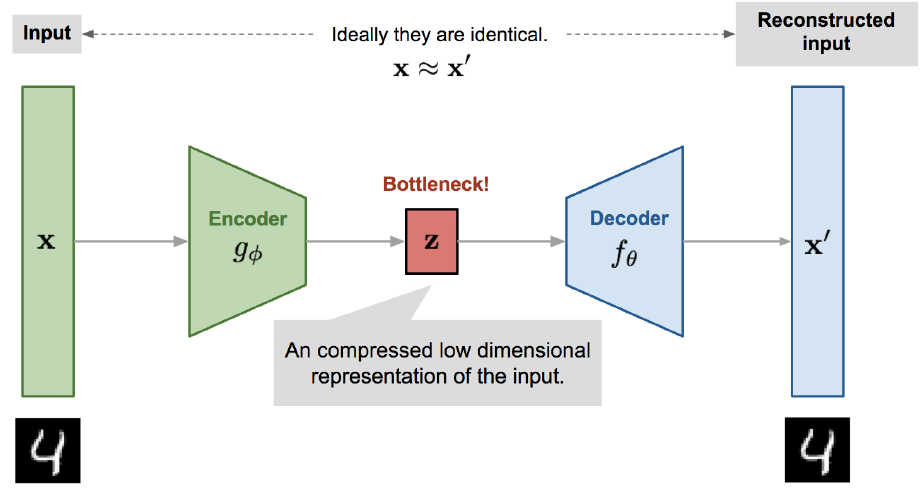

```python
# Reajustar las dimensiones de X_train puesto que Conv1D requiere datos en formato 3D
m, n   = X_train.shape # Dimensiones del dataset train
p, r   = X_test.shape  # Dimensiones del dataset test

X_train_reshaped = X_train.reshape((m, 60, 8))
X_test_reshaped = X_test.reshape((p, 60, 8))
```

# Reajustar las dimensiones de X_train puesto que Conv1D requiere datos en formato 3D m, n = X_train.shape # Dimensiones del dataset train p, r = X_test.shape # Dimensiones del dataset test X_train_reshaped = X_train.reshape((m, 60, 8)) X_test_reshaped = X_test.reshape((p, 60, 8))

```python
# AUTOENCODER
# Definir capa de entrada
input_layer = Input(shape=(60, 8))

# Definir encoder
x           = Conv1D(filters=8, kernel_size=3, activation='relu', padding='same')(input_layer)
bottleneck  = Flatten()(x)
#bottleneck  = Dense(32, activation='relu')(x)

# Definir decoder
#x             = Dense(60 * 8, activation='relu')(bottleneck)
x             = Reshape((60, 8))(bottleneck)
output_layer  = Conv1DTranspose(filters=8, kernel_size=3, activation='sigmoid', padding='same')(x)

# Definir modelo
autoencoder = Model(inputs=input_layer, outputs=output_layer)
autoencoder.compile(optimizer='adam', loss='binary_crossentropy')

# Entrenar autoencoder
history = autoencoder.fit(X_train_reshaped, X_train_reshaped, epochs=20, batch_size=32, validation_split=0.2)
```

# AUTOENCODER # Definir capa de entrada input_layer = Input(shape=(60, 8)) # Definir encoder x = Conv1D(filters=8, kernel_size=3, activation='relu', padding='same')(input_layer) bottleneck = Flatten()(x) #bottleneck = Dense(32, activation='relu')(x) # Definir decoder #x = Dense(60 * 8, activation='relu')(bottleneck) x = Reshape((60, 8))(bottleneck) output_layer = Conv1DTranspose(filters=8, kernel_size=3, activation='sigmoid', padding='same')(x) # Definir modelo autoencoder = Model(inputs=input_layer, outputs=output_layer) autoencoder.compile(optimizer='adam', loss='binary_crossentropy') # Entrenar autoencoder history = autoencoder.fit(X_train_reshaped, X_train_reshaped, epochs=20, batch_size=32, validation_split=0.2)

```
54/54 ━━━━━━━━━━━━━━━━━━━━ 2s 13ms/step - loss: 0.7044 - val_loss: 0.6261
54/54 ━━━━━━━━━━━━━━━━━━━━ 1s 10ms/step - loss: 0.5937 - val_loss: 0.4684
54/54 ━━━━━━━━━━━━━━━━━━━━ 0s 5ms/step - loss: 0.4215 - val_loss: 0.3057
54/54 ━━━━━━━━━━━━━━━━━━━━ 1s 5ms/step - loss: 0.2815 - val_loss: 0.2242
54/54 ━━━━━━━━━━━━━━━━━━━━ 0s 5ms/step - loss: 0.2105 - val_loss: 0.1758
54/54 ━━━━━━━━━━━━━━━━━━━━ 0s 5ms/step - loss: 0.1660 - val_loss: 0.1404
54/54 ━━━━━━━━━━━━━━━━━━━━ 1s 5ms/step - loss: 0.1325 - val_loss: 0.1122
54/54 ━━━━━━━━━━━━━━━━━━━━ 0s 5ms/step - loss: 0.1057 - val_loss: 0.0897
54/54 ━━━━━━━━━━━━━━━━━━━━ 0s 5ms/step - loss: 0.0842 - val_loss: 0.0718
54/54 ━━━━━━━━━━━━━━━━━━━━ 0s 5ms/step - loss: 0.0673 - val_loss: 0.0577
54/54 ━━━━━━━━━━━━━━━━━━━━ 0s 5ms/step - loss: 0.0539 - val_loss: 0.0466
54/54 ━━━━━━━━━━━━━━━━━━━━ 0s 5ms/step - loss: 0.0435 - val_loss: 0.0380
54/54 ━━━━━━━━━━━━━━━━━━━━ 0s 5ms/step - loss: 0.0354 - val_loss: 0.0313
54/54 ━━━━━━━━━━━━━━━━━━━━ 1s 5ms/step - loss: 0.0291 - val_loss: 0.0261
54/54 ━━━━━━━━━━━━━━━━━━━━ 0s 5ms/step - loss: 0.0241 - val_loss: 0.0220
54/54 ━━━━━━━━━━━━━━━━━━━━ 0s 5ms/step - loss: 0.0202 - val_loss: 0.0187
54/54 ━━━━━━━━━━━━━━━━━━━━ 0s 5ms/step - loss: 0.0172 - val_loss: 0.0162
54/54 ━━━━━━━━━━━━━━━━━━━━ 0s 5ms/step - loss: 0.0147 - val_loss: 0.0141
54/54 ━━━━━━━━━━━━━━━━━━━━ 0s 5ms/step - loss: 0.0127 - val_loss: 0.0124
54/54 ━━━━━━━━━━━━━━━━━━━━ 0s 5ms/step - loss: 0.0111 - val_loss: 0.0110
```

```python
# Evaluar la pérdida de reconstrucción del autoencoder
train_loss  = autoencoder.evaluate(X_train_reshaped, X_train_reshaped)
test_loss   = autoencoder.evaluate(X_test_reshaped, X_test_reshaped)

print(f"\nTrain loss: {train_loss:.4f}")
print(f"Test loss: {test_loss:.4f}")
```

# Evaluar la pérdida de reconstrucción del autoencoder train_loss = autoencoder.evaluate(X_train_reshaped, X_train_reshaped) test_loss = autoencoder.evaluate(X_test_reshaped, X_test_reshaped) print(f"\nTrain loss: {train_loss:.4f}") print(f"Test loss: {test_loss:.4f}")

```
67/67 ━━━━━━━━━━━━━━━━━━━━ 0s 2ms/step - loss: 0.0101
33/33 ━━━━━━━━━━━━━━━━━━━━ 0s 3ms/step - loss: 0.0101

Train loss: 0.0103
Test loss: 0.0101
```

```python
# Visualizar la curva de entrenamiento del autoencoder
plt.plot(history.history['loss'], label='Train loss')
plt.plot(history.history['val_loss'], label='Validation loss')
plt.legend()
plt.xlabel('Epoch')
plt.ylabel('Loss')
plt.title('Pérdida de entrenamiento vs validación')
plt.show()
```

# Visualizar la curva de entrenamiento del autoencoder plt.plot(history.history['loss'], label='Train loss') plt.plot(history.history['val_loss'], label='Validation loss') plt.legend() plt.xlabel('Epoch') plt.ylabel('Loss') plt.title('Pérdida de entrenamiento vs validación') plt.show()

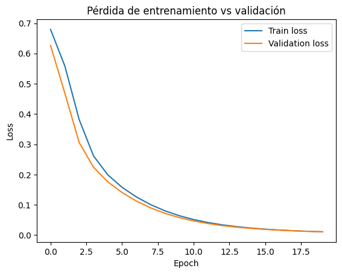

**We observe that the autoencoder quality is good since the reconstruction loss is very low.**

```python
# Extraer la parte codificadora "encoder" para usarla en otros modelos
encoder = Model(inputs=input_layer, outputs=bottleneck)
X_train_encoded = encoder.predict(X_train_reshaped)
```

# Extraer la parte codificadora "encoder" para usarla en otros modelos encoder = Model(inputs=input_layer, outputs=bottleneck) X_train_encoded = encoder.predict(X_train_reshaped)

```
67/67 ━━━━━━━━━━━━━━━━━━━━ 0s 2ms/step
```

```python
# Verificar las dimensiones de las nuevas coordenadas de X_train_encoded
X_train_encoded.shape, X_train.shape
```

# Verificar las dimensiones de las nuevas coordenadas de X_train_encoded X_train_encoded.shape, X_train.shape

```
((2129, 480), (2129, 480))
```

```python
# Visualizar X_train_encoded
print(X_train_encoded)
```

# Visualizar X_train_encoded print(X_train_encoded)

```
[[0.41865867 1.1792793  0.         ... 1.0533024  1.2378863  1.4537132 ]
 [0.97194517 1.2243328  0.7337566  ... 1.6940844  0.6968196  2.2641408 ]
 [0.7622293  0.27394313 1.5169445  ... 1.1491497  1.7781353  0.6089502 ]
 ...
 [0.         0.19901627 1.6442008  ... 0.92114854 1.2606764  0.        ]
 [0.55828255 1.0124682  0.6177381  ... 1.4002684  0.5707153  1.0705616 ]
 [0.18931112 0.25097656 1.0731099  ... 2.1333911  0.10522419 1.4503322 ]]
```

```python
# Obtener las nuevas coordenadas de X_test
X_test_encoded = encoder.predict(X_test_reshaped)
```

# Obtener las nuevas coordenadas de X_test X_test_encoded = encoder.predict(X_test_reshaped)

```
33/33 ━━━━━━━━━━━━━━━━━━━━ 0s 2ms/step
```

```python
# Verificar las dimensiones de las nuevas coordenadas de X_test_encoded
X_test_encoded.shape, X_test.shape
```

# Verificar las dimensiones de las nuevas coordenadas de X_test_encoded X_test_encoded.shape, X_test.shape

```
((1049, 480), (1049, 480))
```

```python
# Visualizar X_test_encoded
print(X_test_encoded)
```

# Visualizar X_test_encoded print(X_test_encoded)

```
[[0.18931112 0.25097656 1.0731099  ... 0.8388007  1.4651122  1.0704793 ]
 [0.55828255 1.0124682  0.6177381  ... 1.4002684  0.5707153  1.0705616 ]
 [0.55828255 1.0124682  0.6177381  ... 0.8388007  1.4651122  1.0704793 ]
 ...
 [0.34228757 1.3086706  0.33683705 ... 1.0533024  1.2378863  1.4537132 ]
 [1.4116294  0.32590342 0.94585365 ... 1.0568092  1.7025597  1.0396074 ]
 [0.16956863 0.1146785  2.0411205  ... 1.7764323  0.49238378 1.1906232 ]]
```